# Another snapshot of my work in R

2023-05-15

# Money in UK politics

[The Westminster Accounts](https://news.sky.com/story/the-westminster-accounts-12786091), a recent collaboration between Sky News and Tortoise Media, examines the flow of money through UK politics. It does so by combining data from three key sources:

1. [Register of Members’ Financial Interests](https://www.parliament.uk/mps-lords-and-offices/standards-and-financial-interests/parliamentary-commissioner-for-standards/registers-of-interests/register-of-members-financial-interests/),
2. [Electoral Commission records of donations to parties](http://search.electoralcommission.org.uk/English/Search/Donations), and
3. [Register of All-Party Parliamentary Groups](https://www.parliament.uk/mps-lords-and-offices/standards-and-financial-interests/parliamentary-commissioner-for-standards/registers-of-interests/register-of-all-party-party-parliamentary-groups/).

## Open a connection to the database

The database made available by Simon Willison is an `SQLite` database

```r
sky_westminster <- DBI::dbConnect(
  drv = RSQLite::SQLite(),
  dbname = here::here("data", "sky-westminster-files.db")
)
```

How many tables does the database have?

```r
DBI::dbListTables(sky_westminster)
```

```
## [1] "appg_donations"  "appgs"           "member_appgs"    "members"
## [5] "parties"         "party_donations" "payments"
```

There 7 tables in this database.

## Which MP has received the most amount of money?

```r
#creating the object for members
members_db <- tbl(sky_westminster,"members")


#This is code that I derived with help from ChatGPT in order to extract the year from the date column in payments
data <- dbGetQuery(sky_westminster, "SELECT * FROM payments")

data$year <- str_extract(data$date, "\\d{4}")

dbWriteTable(sky_westminster, "payments", data, overwrite = TRUE)


#creating the object for payments
payments_db <- tbl(sky_westminster,"payments")



#joining payments and members
member_payments_db <- left_join(payments_db ,members_db %>%

                                  rename(member_id = "id"), by = "member_id") %>%

  select(name, party_id, member_id, entity, value, year)



#determining the value of donations by MP
max_mp_payment_dp <- member_payments_db %>%

  group_by(name) %>%

  summarise(total_donations = sum(value, na.rm = TRUE)) %>%

  arrange(desc(total_donations))

max_mp_payment_dp
```

```
## # Source:     SQL [?? x 2]
## # Database:   sqlite 3.39.3 [/Users/patrickhofbauer/Desktop/Hofbauer_Site/data/sky-westminster-files.db]
## # Ordered by: desc(total_donations)
##    name             total_donations
##    <chr>                      <dbl>
##  1 Theresa May             2809765.
##  2 Sir Geoffrey Cox        2191387.
##  3 Boris Johnson           1282402
##  4 Keir Starmer             799936.
##  5 Andrew Mitchell          769373.
##  6 Fiona Bruce              712321.
##  7 John Redwood             692438.
##  8 Rishi Sunak              546043
##  9 Liz Truss                538678.
## 10 Ed Davey                 441681.
## # ℹ more rows
```

As we can see in the table, Theresa May received the highest amount of donations at 2,809,765.42 GBP

## Any `entity` that accounts for more than 5% of all donations?

Is there any `entity` whose donations account for more than 5% of the total payments given to MPs over the 2020-2022 interval? Who are they and who did they give money to?

```r
#determining entities with 5% or higher
entity_donations <- member_payments_db %>%

  group_by(entity) %>%

  summarise(total_donations = sum(value,na.rm = TRUE)) %>%

  mutate(overall_total = sum(total_donations, na.rm = TRUE)) %>% mutate(share = total_donations/overall_total) %>%

  arrange(desc(share))

entity_donations
```

```
## # Source:     SQL [?? x 4]
## # Database:   sqlite 3.39.3 [/Users/patrickhofbauer/Desktop/Hofbauer_Site/data/sky-westminster-files.db]
## # Ordered by: desc(share)
##    entity                                total_donations overall_total   share
##    <chr>                                           <dbl>         <dbl>   <dbl>
##  1 Withers LLP                                  1812732.     34520598. 0.0525
##  2 Fiona Bruce and Co LLP                        711749.     34520598. 0.0206
##  3 Charles Stanley                               674821.     34520598. 0.0195
##  4 Unite                                         636313.     34520598. 0.0184
##  5 Cambridge Speaker Series                      408200      34520598. 0.0118
##  6 GMB Union                                     397738.     34520598. 0.0115
##  7 MPM Connect                                   345217      34520598. 0.0100
##  8 Centerview Partners LLP                       277724.     34520598. 0.00805
##  9 Council of Insurance Agents & Brokers         276130      34520598. 0.00800
## 10 Hindustan Times                               261652.     34520598. 0.00758
## # ℹ more rows
```

Whiters LLP is the only entity that has more than 5% in donation share.

```r
#retrieving the distinct MPs that Whithers donated to
whiters_donations <- member_payments_db %>%

  filter(entity == "Withers LLP") %>%

  group_by(name) %>%

  summarise(total_donations = sum(value, na.rm = TRUE))

whiters_donations
```

```
## # Source:   SQL [1 x 2]
## # Database: sqlite 3.39.3 [/Users/patrickhofbauer/Desktop/Hofbauer_Site/data/sky-westminster-files.db]
##   name             total_donations
##   <chr>                      <dbl>
## 1 Sir Geoffrey Cox        1812732.
```

They donated all 1,812,732 GBP to Geoffrey Cox

## Do `entity` donors give to a single party or not?

- How many distinct entities who paid money to MPS are there?
- How many (as a number and %) donated to MPs belonging to a single party only?

```r
#determining number of distinct entities
member_payments_db %>%

  group_by(entity) %>%

  summarise(sum = n()) %>%

  ungroup() %>%

  summarise(entities = n())
```

```
## # Source:   SQL [1 x 1]
## # Database: sqlite 3.39.3 [/Users/patrickhofbauer/Desktop/Hofbauer_Site/data/sky-westminster-files.db]
##   entities
##      <int>
## 1     2213
```

There are 2213 distinct entities.

```r
#creating the object for the partie database
parties_db <- tbl(sky_westminster,"parties")



#joining parties with the already joined mebers and payments tables
party_payment_db <- left_join(member_payments_db,parties_db %>%

                                rename(party_id = "id",Party = "name"), by = "party_id")



#determining number of entities that have contributed to only one party
party_payment_db %>%

  group_by(entity,Party) %>%

  summarise(donations = sum(value, na.rm = TRUE),.groups = "drop_last") %>% #simply summarising to be able to count the rows created from the grouping

  summarise(entity_party = n(),.groups = "drop_last") %>% #counting the number of contributions by entity

  filter(entity_party == 1) %>% #filtering for entities that have only contributed once (one party only)

  summarise(solo_contributors = n())
```

```
## # Source:   SQL [1 x 1]
## # Database: sqlite 3.39.3 [/Users/patrickhofbauer/Desktop/Hofbauer_Site/data/sky-westminster-files.db]
##   solo_contributors
##               <int>
## 1              2036
```

2036 of these entities only contributed to one party.

```r
#creating a dataframe manually because after left joining the two previous summaries it returns 0 when mutating for a share
solo_entity_share <- tibble(total_entities = 2213,solo_contributors = 2036, share = 2036/2213 )

solo_entity_share
```

```
## # A tibble: 1 × 3
##   total_entities solo_contributors share
##            <dbl>             <dbl> <dbl>
## 1           2213              2036 0.920
```

This is a share of 92%

## Which party has raised the greatest amount of money in each of the years 2020-2022?

- Write code that visualizes the required data according to the following table

[figure not shown]

```r
#pulling party donations from the database list
party_donations_db <- tbl(sky_westminster,"party_donations")

#changing the string date into a year integer
party_donations_db <- party_donations_db %>%

  mutate(year = year(date)) %>%

  select(-date,-nature_of_donation,-donation_id) #dropping unnecessary columns


#matching party donations with party information to match for party names
party_name_donations_db <- left_join(party_donations_db,parties_db %>%

                                    rename(party_id = "id"), by = "party_id") %>%

  select(-party_id,-abbrev,-background,-foreground,-entity) %>% #dropping unnecessary columns

  relocate(name) %>% #resorting columns according to screenshot

  relocate(year)

  #determining party contribution by year
donations_by_party_year_db <- party_name_donations_db %>%

  filter(year > 2019) %>%

  group_by(year,name) %>%

  summarise(total_year_donations = sum(value, na.rm = TRUE),.groups = "drop_last") %>%

  group_by(year) %>%

  mutate(sum = sum(total_year_donations, na.rm = TRUE),prop = total_year_donations/sum) %>% #calculate yearly proportion by party

  select(-sum) #drop temporary column needed for prop calculation

#removing scientific notation
options(scipen = 999)


donations_by_party_year_db
```

```
## # Source:   SQL [?? x 4]
## # Database: sqlite 3.39.3 [/Users/patrickhofbauer/Desktop/Hofbauer_Site/data/sky-westminster-files.db]
## # Groups:   year
##     year name                    total_year_donations    prop
##    <int> <chr>                                  <dbl>   <dbl>
##  1  2020 Alliance                             105000  0.00150
##  2  2020 Conservative                       42770782. 0.612
##  3  2020 Green Party                          378068  0.00541
##  4  2020 Labour                             13539803. 0.194
##  5  2020 Liberal Democrats                  12717295. 0.182
##  6  2020 Plaid Cymru                           70000  0.00100
##  7  2020 Scottish National Party              246284. 0.00352
##  8  2020 Sinn Féin                            113892  0.00163
##  9  2021 Alba Party                            53559. 0.00180
## 10  2021 Alliance                              42500  0.00142
## # ℹ more rows
```

- Based on the data, plot the following chart

[figure not shown]

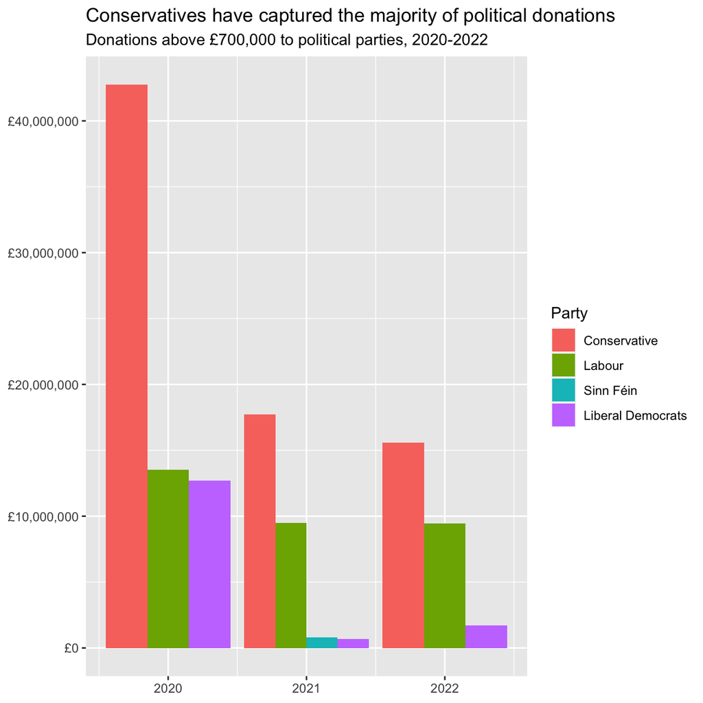

```r
#turning database into dataframe
party_donation_df <- donations_by_party_year_db %>%

  collect() %>%

  filter(total_year_donations > 700000) %>% #filtering out parties with less than 700,000 in donations

  #adding factor levels according to contribution levels for graph sorting
  mutate(Party = factor(name, levels = c("Conservative","Labour","Sinn Féin","Liberal Democrats")))


#plotting column chart
ggplot(party_donation_df, aes(year,total_year_donations, fill=Party)) +

  geom_col(position = "dodge") +

  labs(title = "Conservatives have captured the majority of political donations", subtitle = "Donations above £700,000 to political parties, 2020-2022", x = NULL, y = NULL) +

  #adding GBP and comma to the y-axis
  scale_y_continuous(labels = scales::label_dollar(prefix = "£"))
```

Finally, when you are done working with the databse, make sure you close the connection, or disconnect from the database.

```r
dbDisconnect(sky_westminster)
```